# ANOVA & Tukey HSD test

Eve Boyle

March 10, 2015

# Cerling et al. 2013 - Diet of *Theropithecus* from 4 to 1 Ma in Kenya

## Let’s read in these data:

```r
baboondiet <- read.csv("http://hompal-stats.wabarr.com/datasets/Cerling_etal_2013.csv", header = TRUE)
head(baboondiet)
```

```
##        Taxon Delta.C13
## 1 T. brumpti      -7.2
## 2 T. brumpti      -4.2
## 3 T. brumpti      -3.0
## 4 T. brumpti      -3.2
## 5 T. brumpti      -2.3
## 6 T. brumpti      -3.6
```

#### Before we run the ANOVA, we should take examine some general patterns in the data to A) make sure that our data conform to the assumptions of ANOVA and B) so we can interpret the results of the analysis later on.

```r
tapply(baboondiet$Delta.C13, baboondiet$Taxon, mean)
```

```
##     P. boisei   P. robustus     Papio sp.    T. brumpti T. oswaldi EA
##    -1.2692308    -7.4818182    -9.7625000    -3.5533333    -0.6655172
## T. oswaldi SA
##    -2.3181818
```

```r
tapply(baboondiet$Delta.C13, baboondiet$Taxon, var)
```

```
##     P. boisei   P. robustus     Papio sp.    T. brumpti T. oswaldi EA
##     0.8702154     1.4167965     9.8841848     2.4612381     2.1244828
## T. oswaldi SA
##     2.4736364
```

```r
tapply(baboondiet$Delta.C13, baboondiet$Taxon, length)
```

```
##     P. boisei   P. robustus     Papio sp.    T. brumpti T. oswaldi EA
##            26            22            24            15            29
## T. oswaldi SA
##            11
```

Hmm, *Papio* sp. has a much larger variance than the other groups. This is likely due to the inclusion of two species (*P. anubis* and *P. hamadryas*) within the category. The authors were more interested in comparing the modern baboons to fossil baboons, not distinguishing between the modern groups. So we can let this fly…

## Perform the ANOVA

This can be done utilizing anova() or aov(), but you may prefer one over the other depending on what information you need.

What do the help pages tell us?

```r
?anova
?aov
```

So, the purpose of anova() is simply to generate ANOVA tables for a fitted model, while while aov() performs the actual analysis of variance (hence their names…).

### Getting an ANOVA table using anova(lm())

```r
baboonanova <- anova(lm(Delta.C13 ~ Taxon, data = baboondiet))
baboonanova
```

```
## Analysis of Variance Table
##
## Response: Delta.C13
##            Df  Sum Sq Mean Sq F value    Pr(>F)
## Taxon       5 1610.29  322.06  98.029 < 2.2e-16 ***
## Residuals 121  397.52    3.29
## ---
## Signif. codes:  0 '***' 0.001 '**' 0.01 '*' 0.05 '.' 0.1 ' ' 1
```

### Getting an ANOVA table using aov()

```r
baboonaov <- aov(Delta.C13 ~ Taxon, data = baboondiet)
baboonaov
```

```
## Call:
##    aov(formula = Delta.C13 ~ Taxon, data = baboondiet)
##
## Terms:
##                     Taxon Residuals
## Sum of Squares  1610.2854  397.5236
## Deg. of Freedom         5       121
##
## Residual standard error: 1.812545
## Estimated effects may be unbalanced
```

```r
summary(baboonaov)
```

```
##              Df Sum Sq Mean Sq F value Pr(>F)
## Taxon         5 1610.3   322.1   98.03 <2e-16 ***
## Residuals   121  397.5     3.3
## ---
## Signif. codes:  0 '***' 0.001 '**' 0.01 '*' 0.05 '.' 0.1 ' ' 1
```

The p-value suggests that we can reject the null hypothesis, indicating that there is a significant, non-random difference between our 6 group means.

But exactly **which** groups actually differ from one another?

This can be tested with with Tukey’s HSD test, for which you must use your saved aov() results, NOT the results from anova(lm()).

## Tukey’s HSD test - Mind your p’s:

```r
TukeyHSD(baboonaov)
```

```
##   Tukey multiple comparisons of means
##     95% family-wise confidence level
##
## Fit: aov(formula = Delta.C13 ~ Taxon, data = baboondiet)
##
## $Taxon
##                                   diff        lwr        upr     p adj
## P. robustus-P. boisei       -6.2125874 -7.7331228 -4.6920520 0.0000000
## Papio sp.-P. boisei         -8.4932692 -9.9790907 -7.0074477 0.0000000
## T. brumpti-P. boisei        -2.2841026 -3.9860007 -0.5822045 0.0022557
## T. oswaldi EA-P. boisei      0.6037135 -0.8139384  2.0213654 0.8196977
## T. oswaldi SA-P. boisei     -1.0489510 -2.9369066  0.8390045 0.5942812
## Papio sp.-P. robustus       -2.2806818 -3.8299831 -0.7313805 0.0005643
## T. brumpti-P. robustus       3.9284848  2.1708939  5.6860758 0.0000000
## T. oswaldi EA-P. robustus    6.8163009  5.3322505  8.3003514 0.0000000
## T. oswaldi SA-P. robustus    5.1636364  3.2253265  7.1019463 0.0000000
## T. brumpti-Papio sp.         6.2091667  4.4815198  7.9368135 0.0000000
## T. oswaldi EA-Papio sp.      9.0969828  7.6485203 10.5454452 0.0000000
## T. oswaldi SA-Papio sp.      7.4443182  5.5331188  9.3555175 0.0000000
## T. oswaldi EA-T. brumpti     2.8878161  1.2184344  4.5571977 0.0000274
## T. oswaldi SA-T. brumpti     1.2351515 -0.8484690  3.3187720 0.5235746
## T. oswaldi SA-T. oswaldi EA -1.6526646 -3.5113615  0.2060324 0.1114975
```

*T. brumpti* and East African *T. oswaldi* differ from each other, East African *T. oswaldi* and *P. boisei* are statistically indifferent, and South African *T. oswaldi* is statistically the same to all of these taxa.

δ13C values for modern baboons are significantally different from those of fossil baboons and hominins, though there is some overlap with *P. robustus*.

This is perhaps best understood visually, so let’s replicate the boxplot from the paper…

## Take a look:

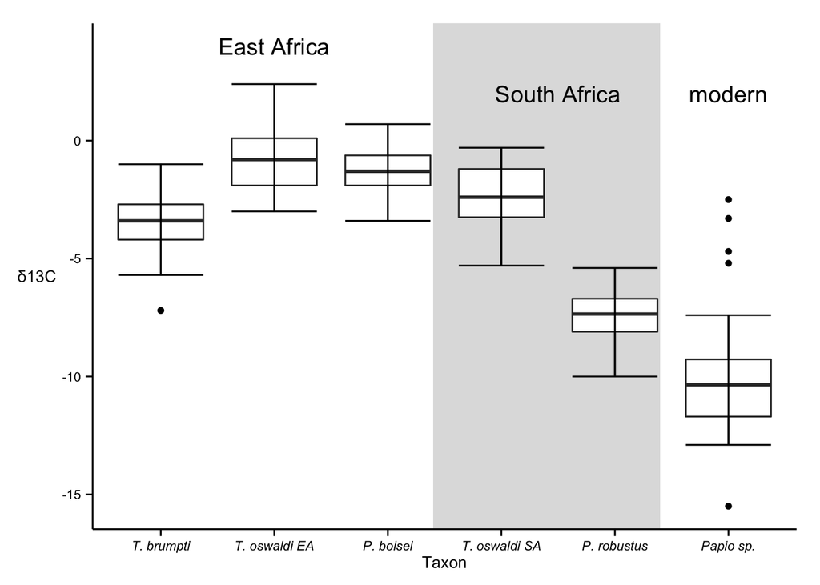

```r
library(ggplot2)

ggplot(data = baboondiet, aes(x = Taxon, y = Delta.C13)) + geom_rect(aes(xmin = 3.4, xmax = 5.4, ymin = -Inf, ymax = Inf), fill = "gray88", alpha = 0.05) + geom_boxplot() + stat_boxplot(geom = 'errorbar') + xlim("T. brumpti", "T. oswaldi EA", "P. boisei", "T. oswaldi SA", "P. robustus", "Papio sp.") + ylab("δ13C") + annotate("text", x=2, y=4, label = "East Africa" , size = 5) + annotate("text", x = 4.5, y = 2, label = "South Africa", size = 5) + annotate("text", x = 6, y = 2, label = "modern", size = 5) + theme_classic(10) + theme(axis.title.y = element_text(angle=0), axis.text.x = element_text(face = "italic"))
```

Beautiful!